# TUTORIAL: One dataset, four meta-analyses: synthesising mean effects, within-population variability, and between-population heterogeneity in ecology

#### lnCVR

```r
form_ls_ma2 <- bf(lnCVR ~ 1 + Org.fertilizer.type +
                    (1|study_ID) + # this is u_l (the between-study effect)
                    (1|gr(effect_size_ID, cov = vcv)), # this is m (sampling error)
                  sigma ~ 1 +  Org.fertilizer.type
                  )

# generate default priors
prior_ls_ma2 <- default_prior(form_ls_ma2,
                              data=dat,
                              data2=list(vcv=vcv),
                              family=gaussian())

prior_ls_ma2$prior[5] = "constant(1)" # meta-analysis assumes

# fitting model
fit_ls_ma2 <- brm(
  formula = form_ls_ma2,
  data = dat,
  data2 = list(vcv=vcv),
  chains = 2,
  cores = 2,
  iter = 6000,
  warmup = 3000,
  prior = prior_ls_ma2,
  control = list(adapt_delta=0.95, max_treedepth=15)
  )
summary(fit_ls_ma2)
# Family: gaussian
#   Links: mu = identity; sigma = log
# Formula: lnCVR ~ 1 + Org.fertilizer.type + (1 | study_ID) + (1 | gr(effect_size_ID, cov = vcv))
#          sigma ~ 1 + Org.fertilizer.type
#    Data: dat (Number of observations: 318)
#   Draws: 2 chains, each with iter = 6000; warmup = 3000; thin = 1;
#          total post-warmup draws = 6000
#
# Multilevel Hyperparameters:
# ~effect_size_ID (Number of levels: 318)
#               Estimate Est.Error l-95% CI u-95% CI Rhat Bulk_ESS Tail_ESS
# sd(Intercept)     1.00      0.00     1.00     1.00   NA       NA       NA
#
# ~study_ID (Number of levels: 36)
#               Estimate Est.Error l-95% CI u-95% CI Rhat Bulk_ESS Tail_ESS
# sd(Intercept)     0.26      0.08     0.12     0.43 1.00     1516     2572
#
# Regression Coefficients:
#                                Estimate Est.Error l-95% CI u-95% CI Rhat Bulk_ESS Tail_ESS
# Intercept                          0.30      0.09     0.13     0.48 1.00     4592     4409
# sigma_Intercept                   -0.83      0.13    -1.09    -0.58 1.00     1518     2937
# Org.fertilizer.typeplant           0.08      0.13    -0.17     0.32 1.00     4734     4478
# sigma_Org.fertilizer.typeplant     0.51      0.18     0.15     0.87 1.00     1459     2679
#
# Draws were sampled using sampling(NUTS). For each parameter, Bulk_ESS
# and Tail_ESS are effective sample size measures, and Rhat is the potential
# scale reduction factor on split chains (at convergence, Rhat = 1).
```

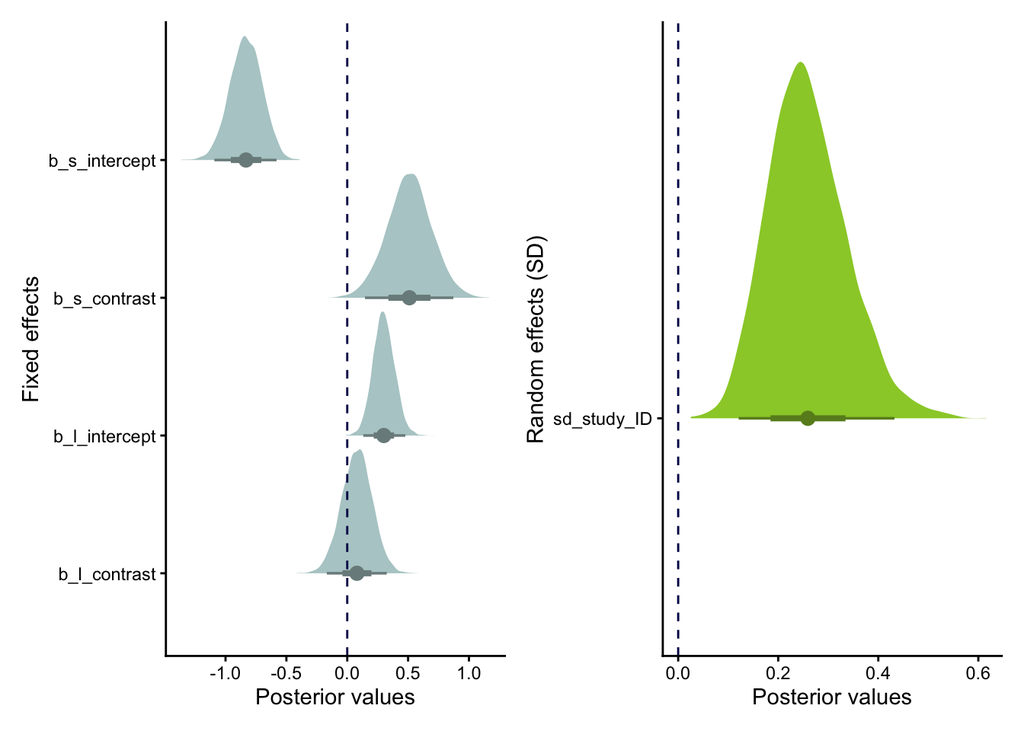

For lnCVR, the location component indicated that organic systems tend to exhibit higher mean-corrected variability under animal-based fertilisers ($\beta^{(l)}_{\text{animal}}$ = 0.30, 95% CrI = [0.13, 0.48]), corresponding to an average CV ratio of (0.30) $\approx$ 1.35 - roughly 35% higher variability in organic relative to conventional systems.

The contrast coefficient for fertiliser type in the location component was small and highly uncertain ($\beta^{(l)}_{\text{animal-plant}}$ = 0.08, 95% CrI [−0.17, 0.32]), suggesting that fertiliser category does not systematically shift the average within-group variability contrast between organic and conventional systems.

In contrast, the scale component revealed clear evidence that residual heterogeneity in lnCVR differs by fertiliser type. Residual heterogeneity was substantially larger under plant-based fertilisers $(\beta^{(s)}_{\text{animal-plant}}$ = 0.51, 95% CrI [0.15, 0.87]), corresponding to a multiplicative increase in residual variability of approximately 68% ((0.51) $\approx$ 1.68). Under this model, the implied residual standard deviation for lnCVR under plant-based fertilisers is $\sigma \approx \exp$(-0.83 + 0.51) $\approx$ 0.73.

Thus, while the expected within-group variability contrast (lnCVR) is broadly similar across fertiliser categories, lnCVR effects are more dispersed among the represented comparisons under plant-based fertilisers. This residual-scale result does not by itself show poorer transferability to a genuinely new study; the study-level extension below addresses that separate question.

**B and C. Random effects/Correlated random effects in location and scale components**

The models presented here extend the basic location–scale meta-regression by adding a study-level random effect to the residual log-SD. This allows residual dispersion to vary among studies; it is distinct from allowing the SD of study-level mean effects to differ between fertiliser categories.

These models are included for completeness and to illustrate the flexibility of `brms`. In practice, they are often difficult to fit reliably and should be treated as advanced extensions rather than default choices. Accordingly, we provide example code but do not interpret the results in detail.

For transparency, examples in which the models were run but failed to converge are also documented in this [online tutorial](https://itchyshin.github.io/location-scale_meta-analysis/). You can also find more examples of complex location-scale models in another [online tutorial](https://ayumi-495.github.io/Eco_location-scale_model/), though these are not specific to meta-analysis.

**1. with random effects in scale component**

In the model with the random effects in the scale component, we can include random effects in the scale component, allowing residual heterogeneity to vary across studies. If we want to specify such a model, we can do so as follows:

```r
sigma ~ 1 + Org.fertilizer.type + (1 | study_ID)
```

This specification allows the residual variance to vary across studies, in addition to allowing study-level variation in the mean effect size via the location component. Conceptually, the location component models how the mean effect size varies with the moderator and across studies. The scale component models how the amount of unexplained variability differs across studies and fertiliser types.

Random effects in the location and scale components are assumed to be independent in this formulation.

**2. Correlated random effects in location and scale components**

The next model further extends the previous formulation by allowing correlated random effects between the location and scale components. For example, if we want to consider potential correlations between study-level deviations in mean effect sizes and deviations in residual variance, we can specify the model as follows:

```r
(1 | p | study_ID)
```

This specification allows the model to estimate the correlation between study-level deviations in the mean effect size and deviations in residual variance.

For example, a negative correlation would indicate that studies with larger mean effects tend to show lower residual variability, whereas a positive correlation would suggest the opposite. Such relationships are conceptually appealing and biologically interpretable in some contexts.

However, this model is computationally demanding and highly sensitive to prior specification and data structure. In applied meta-analyses, it frequently exhibits convergence problems or weakly identified correlation parameters.

## glmmTMB

In contrast to `metafor`, `glmmTMB` allows us to include random effects in both location and scale components - we demonstrate how to fit a location-scale meta-regression model using `glmmTMB`.

But it should be mentioned that `glmmTMB` does not support correlated random effects between location and scale components, so the third model presented above cannot be implemented using `glmmTMB`.

Again, the same as `brms`, we focus on a location–scale meta-regression model with fixed effects in the scale component.

**Keep in your mind…**

In the location–scale models by `glmmTMB`, dispersion parameters are modelled on the log standard deviation scale ($ln(\sigma)$). All coefficients for the scale component should therefore be interpreted as effects on the log standard deviation, not on the variance.

### A. Only fixed effects in scale component

In `glmmTMB`, the location–scale structure is implemented by separating the model into a *conditional* component and a *dispersion* component. The conditional model specifies the mean structure of the response (location), while the dispersion model specifies how the residual variance changes as a function of predictors (scale). Note that the dispersion model in `glmmTMB` does not describe an additional random effect, but rather models heteroscedasticity in the residual variance on the log scale.

#### lnRR

```r
glmm_lnRR1 <- glmmTMB(lnRR ~ 1 + Org.fertilizer.type + (1 | study_ID) +
                      equalto(0 + effect_size_ID|g, vcv),
                  dispformula = ~ 1 + Org.fertilizer.type, # scale component
                  data = dat,
                  REML = TRUE)
summary(glmm_lnRR1)
#  Family: gaussian  ( identity )
# Formula:          lnRR ~ 1 + Org.fertilizer.type + (1 | study_ID) + equalto(0 +      effect_size_ID | g, vcv)
# Dispersion:            ~1 + Org.fertilizer.type
# Data: dat
#
#       AIC       BIC    logLik -2*log(L)  df.resid
#     230.9     249.7    -110.5     220.9       313
#
# Random effects:
#
# Conditional model:
#  Groups   Name             Variance  Std.Dev. Corr
#  study_ID (Intercept)      0.0608129 0.24660
#  g        effect_size_ID33 0.0047213 0.06871
#           effect_size_ID34 0.0426425 0.20650  0.00
#           effect_size_ID35 0.0698313 0.26426  0.00 0.00
#           effect_size_ID36 0.0798567 0.28259  0.00 0.00 0.00
#           effect_size_ID37 0.0837435 0.28938  0.00 0.00 0.00 0.00
#           effect_size_ID39 0.0095870 0.09791  0.00 0.00 0.00 0.00 0.00
#           effect_size_ID40 0.0091520 0.09567  0.00 0.00 0.00 0.00 0.00 0.00
#           effect_size_ID42 0.0363323 0.19061  0.00 0.00 0.00 0.00 0.00 0.00 0.00
#           effect_size_ID44 0.0331452 0.18206  0.00 0.00 0.00 0.00 0.00 0.00 0.00 0.00
#           effect_size_ID45 0.0012338 0.03513  0.00 0.00 0.00 0.00 0.00 0.00 0.00 0.00 0.00
#           ...              ...       ...      ...  ...  ...  ...  ...  ...  ...  ...  ...  ...
#  Residual                         NA      NA
# Number of obs: 318, groups:  study_ID, 36; g, 1
#
# Conditional model:
#                          Estimate Std. Error z value Pr(>|z|)
# (Intercept)              -0.26791    0.05379  -4.981 6.33e-07 ***
# Org.fertilizer.typeplant -0.13991    0.05897  -2.373   0.0177 *
# ---
# Signif. codes:  0 ‘***’ 0.001 ‘**’ 0.01 ‘*’ 0.05 ‘.’ 0.1 ‘ ’ 1
#
# Dispersion model:
#                          Estimate Std. Error z value Pr(>|z|)
# (Intercept)              -1.35445    0.07922 -17.097   <2e-16 ***
# Org.fertilizer.typeplant  0.17055    0.09928   1.718   0.0858 .
```

#### lnCVR

```r
library(glmmTMB)
glmm_lnCVR1 <- glmmTMB(lnCVR ~ 1 + Org.fertilizer.type + (1 | study_ID) +
                        equalto(0 + effect_size_ID|g, vcv),
                      dispformula = ~ 1 + Org.fertilizer.type,
                      data = dat,
                      REML = TRUE)
summary(glmm_lnCVR1)
#  Family: gaussian  ( identity )
# Formula:          lnCVR ~ 1 + Org.fertilizer.type + (1 | study_ID) + equalto(0 +      effect_size_ID | g, vcv)
# Dispersion:             ~1 + Org.fertilizer.type
# Data: dat
#
#       AIC       BIC    logLik -2*log(L)  df.resid
#     930.3     949.1    -460.2     920.3       313
#
# Random effects:
#
# Conditional model:
#  Groups   Name             Variance  Std.Dev. Corr
#  study_ID (Intercept)      0.1083168 0.32912
#  g        effect_size_ID33 0.0047213 0.06871
#           effect_size_ID34 0.0426425 0.20650  0.00
#           effect_size_ID35 0.0698313 0.26426  0.00 0.00
#           effect_size_ID36 0.0798567 0.28259  0.00 0.00 0.00
#           effect_size_ID37 0.0837435 0.28938  0.00 0.00 0.00 0.00
#           effect_size_ID39 0.0095870 0.09791  0.00 0.00 0.00 0.00 0.00
#           effect_size_ID40 0.0091520 0.09567  0.00 0.00 0.00 0.00 0.00 0.00
#           effect_size_ID42 0.0363323 0.19061  0.00 0.00 0.00 0.00 0.00 0.00 0.00
#           effect_size_ID44 0.0331452 0.18206  0.00 0.00 0.00 0.00 0.00 0.00 0.00 0.00
#           effect_size_ID45 0.0012338 0.03513  0.00 0.00 0.00 0.00 0.00 0.00 0.00 0.00 0.00
#           ...              ...       ...      ...  ...  ...  ...  ...  ...  ...  ...  ...  ...
#  Residual                         NA      NA
# Number of obs: 318, groups:  study_ID, 36; g, 1
#
# Conditional model:
#                          Estimate Std. Error z value Pr(>|z|)
# (Intercept)               0.32787    0.09283   3.532 0.000413 ***
# Org.fertilizer.typeplant  0.07193    0.15208   0.473 0.636203
# ---
# Signif. codes:  0 ‘***’ 0.001 ‘**’ 0.01 ‘*’ 0.05 ‘.’ 0.1 ‘ ’ 1
#
# Dispersion model:
#                          Estimate Std. Error z value Pr(>|z|)
# (Intercept)              -0.41563    0.07030  -5.913 3.37e-09 ***
# Org.fertilizer.typeplant  0.66519    0.08807   7.553 4.26e-14 ***
```

### B. Random effects in location and scale components

If you want to include random effects in the scale component, you just need to insert them to the `dispformula` part of the model.

```r
glmm_lnRR2 <- glmmTMB(lnRR ~ 1 + Org.fertilizer.type + (1 | study_ID) +
                        equalto(0 + effect_size_ID|g, vcv),
                      dispformula = ~ 1 + Org.fertilizer.type + (1 | study_ID),
                      data = dat,
                      REML = TRUE)
summary(glmm_lnRR2)
#  Family: gaussian  ( identity )
# Formula:          lnRR ~ 1 + Org.fertilizer.type + (1 | study_ID) + equalto(0 +
#     effect_size_ID | g, vcv)
# Dispersion:            ~1 + Org.fertilizer.type + (1 | study_ID)
# Data: dat
#
#       AIC       BIC    logLik -2*log(L)  df.resid
#     177.4     199.9     -82.7     165.4       312
#
# Random effects:
#
# Conditional model:
#  Groups   Name             Variance  Std.Dev. Corr
#  study_ID (Intercept)      0.0570683 0.23889
#  g        effect_size_ID33 0.0047213 0.06871
#           effect_size_ID34 0.0426425 0.20650  0.00
#           effect_size_ID35 0.0698313 0.26426  0.00 0.00
#           effect_size_ID36 0.0798567 0.28259  0.00 0.00 0.00
#           effect_size_ID37 0.0837435 0.28938  0.00 0.00 0.00 0.00
#           effect_size_ID39 0.0095870 0.09791  0.00 0.00 0.00 0.00 0.00
#           effect_size_ID40 0.0091520 0.09567  0.00 0.00 0.00 0.00 0.00 0.00
#           effect_size_ID42 0.0363323 0.19061  0.00 0.00 0.00 0.00 0.00 0.00 0.00
#           effect_size_ID44 0.0331452 0.18206  0.00 0.00 0.00 0.00 0.00 0.00 0.00 0.00
#           effect_size_ID45 0.0012338 0.03513  0.00 0.00 0.00 0.00 0.00 0.00 0.00 0.00 0.00
#           ...              ...       ...      ...  ...  ...  ...  ...  ...  ...  ...  ...  ...
#  Residual                         NA      NA
# Number of obs: 318, groups:  study_ID, 36; g, 1
#
# Dispersion model:
#  Groups   Name        Variance Std.Dev.
#  study_ID (Intercept) 0.06081  0.2466
#  Residual                  NA      NA
# Number of obs: 318, groups:  study_ID, 36
#
# Conditional model:
#                          Estimate Std. Error z value Pr(>|z|)
# (Intercept)              -0.26476    0.04887  -5.417 6.05e-08 ***
# Org.fertilizer.typeplant -0.11847    0.04545  -2.607  0.00914 **
# ---
# Signif. codes:  0 ‘***’ 0.001 ‘**’ 0.01 ‘*’ 0.05 ‘.’ 0.1 ‘ ’ 1
#
# Dispersion model:
#                          Estimate Std. Error z value Pr(>|z|)
# (Intercept)               -1.6225     0.1147  -14.14  < 2e-16 ***
# Org.fertilizer.typeplant   0.4022     0.1406    2.86  0.00424 **
```

# Extension: where does heterogeneity occur?

The location–scale models above allow fertiliser type to change the residual standard deviation among effect sizes within studies. They retain one study-level standard deviation, so they do not test whether the variation among study means also differs between fertiliser categories.

Here we allow fertiliser type to affect both sources of heterogeneity. The distinction is useful because they describe different kinds of variation: between-study heterogeneity determines how much average effects differ among studies, whereas residual heterogeneity describes how much effect sizes differ around their study mean. The models are fitted to lnRR and lnCVR using the same 318 effect sizes from 36 studies.

## Extending the location–scale model

### Random slopes, heteroscedasticity, and scale models

Random slopes, heteroscedastic random effects, and scale models can describe the same variance structure. Consider fertiliser category as a binary moderator, with animal ($A$) and plant ($P$) levels. A random-intercept model assigns every study the same among-study variance,

$$y_{ij}=\beta_A I(g_{ij}=A)+\beta_P I(g_{ij}=P)+u_j+e_{ij}+m_{ij},
\qquad u_j\sim\mathcal N(0,\sigma_u^2).$$

The single random intercept $u_j$ shifts animal and plant effects in study $j$ by the same amount. Consequently, the model assumes the same between-study SD for both fertiliser categories.

A categorical random-coefficient model instead gives each study a deviation for each category,

$$y_{ij}=\beta_A I(g_{ij}=A)+\beta_P I(g_{ij}=P)
+u_{jA}I(g_{ij}=A)+u_{jP}I(g_{ij}=P)+e_{ij}+m_{ij},$$

$$\begin{pmatrix}u_{jA}\\u_{jP}\end{pmatrix}
\sim\mathcal N\!\left[
\begin{pmatrix}0\\0\end{pmatrix},
\begin{pmatrix}
\sigma_{u,A}^2 & \rho_u\sigma_{u,A}\sigma_{u,P}\\
\rho_u\sigma_{u,A}\sigma_{u,P} & \sigma_{u,P}^2
\end{pmatrix}
\right].$$

This structure is a random-slope model because the effect of fertiliser can vary among studies. It is heteroscedastic because the between-study variance can differ between animal and plant fertilisers.

With conventional intercept–slope coding, the study effect is $u_{0j}$ for animal fertiliser and $u_{0j}+u_{1j}$ for plant fertiliser. Therefore,

$$\operatorname{Var}(u_{jA})=\operatorname{Var}(u_{0j}),\qquad
\operatorname{Var}(u_{jP})=\operatorname{Var}(u_{0j}+u_{1j}).$$

The variance of the random slope, $\operatorname{Var}(u_{1j})$, is not the plant variance. Using `0 + fertilizer` gives one random coefficient per category and makes $\sigma_{u,A}$ and $\sigma_{u,P}$ directly visible.

For a categorical moderator, the same two SDs can be written as a scale regression,

$$\log(\sigma_{u,g})=\gamma_0+\gamma_1 I(g=P),$$

so that $\sigma_{u,A}=\exp(\gamma_0)$ and $\sigma_{u,P}=\exp(\gamma_0+\gamma_1)$. Estimating separate category variances and regressing the log SD on category are therefore two parameterisations of the same heteroscedasticity. The scale-regression form extends naturally to continuous moderators and to models with several predictors.

| Formulation | Between-study structure | Interpretation |
| --- | --- | --- |
| Random intercept | `(1 \| study)` | One study SD shared by all moderator values. |
| Categorical random coefficients | `(0 + fertilizer \| study)` | A study SD for each fertiliser category; their correlation may also be estimated. |
| Direct scale regression | `sd(study) ~ fertilizer` | Fertiliser predicts the log study SD. |
| General scale regression | $\log(\sigma_{u,j})=\mathbf z_j^\mathsf T\boldsymbol\gamma$ | Continuous or multiple study-level moderators predict heterogeneity. |

The same connection holds at the residual level: a dispersion formula such as `sigma ~ fertilizer` is a scale model for heteroscedasticity among effect sizes within studies.

### From one scale sub-model to two

Using the notation introduced above, the location sub-model is

$$y_{ij}=\beta_0^{(l)}+\beta_1^{(l)}x_{1,ij}+\cdots+\beta_p^{(l)}x_{p,ij}
+u_j^{(l)}+e_{ij}^{(l)}+m_{ij},$$

but the study and residual random effects now have their own scale sub-models:

$$u_j^{(l)}\sim\mathcal N(0,\sigma_{u,j}^2),\qquad
e_{ij}^{(l)}\sim\mathcal N(0,\sigma_{e,ij}^2),\qquad
m_{ij}\sim\mathcal N(0,v_{ij}),$$

$$\ln(\sigma_{u,j})=
\beta_0^{(s_u)}+\beta_1^{(s_u)}z_{1j}+\cdots+\beta_q^{(s_u)}z_{qj},$$

$$\ln(\sigma_{e,ij})=
\beta_0^{(s_e)}+\beta_1^{(s_e)}w_{1,ij}+\cdots+\beta_r^{(s_e)}w_{r,ij}.$$

Here, $\sigma_{u,j}$ is the between-study SD and $\sigma_{e,ij}$ is the residual within-study SD. The moderators in the location, between-study scale, and within-study scale sub-models need not be the same. A between-study moderator $z_{qj}$ must be constant within study, whereas an effect-size-level moderator $w_{r,ij}$ can vary within study. For correlated sampling errors, the scalar sampling term is replaced by $\mathbf m\sim\mathcal N(\mathbf 0,\mathbf V)$, as in the fitted models below.

The scale coefficients are expressed on the log-SD scale. With animal-based fertiliser as the reference category, exponentiating the plant-minus-animal scale contrast gives a ratio of SDs:

$$R_u=\frac{\sigma_{u,P}}{\sigma_{u,A}}
=\exp\!\left(\beta_{\text{plant-animal}}^{(s_u)}\right),\qquad
R_e=\frac{\sigma_{e,P}}{\sigma_{e,A}}
=\exp\!\left(\beta_{\text{plant-animal}}^{(s_e)}\right).$$

We report $R_u$ and $R_e$ because they express the moderator effect directly on the natural SD scale. A ratio of 1 means equal heterogeneity, a ratio above 1 means greater heterogeneity under plant-based fertiliser, and a ratio below 1 means less. When software models $\ln(\sigma^2)$ rather than $\ln(\sigma)$, the SD ratio is $\exp(\beta/2)$ rather than $\exp(\beta)$.

### How the fertiliser example maps to this model

The full-data model uses one study random coefficient for each fertiliser category and sets their correlation to zero,

$$\boldsymbol\Sigma_u=
\begin{pmatrix}
\sigma_{u,A}^2&0\\
0&\sigma_{u,P}^2
\end{pmatrix}.$$

Only six studies contain both fertiliser categories, so there is little information with which to estimate $\rho_u$. An unstructured model placed the estimated correlation at its boundary; we therefore use the diagonal structure above and interpret only the two category-specific SDs.

### Why two fitting routes are needed

The full dataset contains 318 effects from 36 studies. Six studies contain both fertiliser categories, contributing 86 effects. Mixed-category studies can be retained by the categorical random-coefficient model because each study can have both $u_{jA}$ and $u_{jP}$. A direct study-scale regression assigns one SD predictor to each study, so its predictor must be constant within that study.

| Route | Data | Study-scale parameterisation | Purpose |
| --- | --- | --- | --- |
| Full-data categorical model | 318 effects, 36 studies | Separate animal and plant study random coefficients | Primary analysis; retains mixed-category studies. |
| Direct study-scale model | 232 effects, 30 studies | Fertiliser predictor on $\log(\sigma_{u,j})$ | Matched-subset sensitivity; fertiliser must be constant within study. |

For the direct model,

$$\log(\sigma_{e,ij})=\alpha_0+\alpha_1 I(g_{ij}=P),\qquad
\log(\sigma_{u,j})=\gamma_0+\gamma_1 I(g_j=P).$$

The direct model is therefore fitted to the 30 studies containing only one fertiliser category. To separate differences in parameterisation from differences in data, we also fit the categorical model to exactly this 232-effect subset.

### Current model as a comparator

The current model has one common study SD and fertiliser-specific residual SDs. The table shows the estimates reproduced with `metafor`.

```r
current_comparator <- study_level_models[
  study_level_models$model == "current_common_study_sd" &
    study_level_models$component %in% c("location", "study_sd", "residual_sd", "ratio"),
  c("response", "component", "term", "estimate")
]
knitr::kable(round_numeric_columns(current_comparator), row.names = FALSE)
```

Reproduction of the current model: common study SD and category-specific residual SD.

| response | component | term | estimate |
| --- | --- | --- | --- |
| lnRR | location | animal | -0.268 |
| lnRR | location | plant | -0.408 |
| lnRR | study_sd | study_ID | 0.247 |
| lnRR | residual_sd | animal | 0.258 |
| lnRR | residual_sd | plant | 0.306 |
| lnRR | ratio | residual_plant_animal | 1.186 |
| lnCVR | location | animal | 0.299 |
| lnCVR | location | plant | 0.383 |
| lnCVR | study_sd | study_ID | 0.236 |
| lnCVR | residual_sd | animal | 0.433 |
| lnCVR | residual_sd | plant | 0.728 |
| lnCVR | ratio | residual_plant_animal | 1.681 |

In `brms`, `se(sqrt(vi), sigma = TRUE)` treats the sampling SD as known while retaining a separate residual SD, `sigma`. This distinction is required when both sampling error and residual heterogeneity are present.

### Full-data categorical study-SD models

The following calls show equivalent implementations of the full-data categorical model.

#### `metafor`

The primary likelihood model uses diagonal animal- and plant-specific random-effect structures at both study and residual levels.

```r
metafor::rma.mv(
  yi = data[[response]],
  V = data[[variance]],
  mods = ~ 0 + fertilizer,
  random = list(
    ~ fertilizer | study_ID,
    ~ fertilizer | effect_size_ID
  ),
  struct = c("DIAG", "DIAG"),
  test = "t",
  method = "REML",
  data = data
)

# Exploratory only: replace the first structure with "UN" to estimate
# the animal--plant study-effect correlation.
```

#### `glmmTMB`

The same declared likelihood can be fitted using `diag()` for the study effects, a fertiliser-specific dispersion model, and `equalto()` for the known sampling covariance.

```r
glmmTMB::glmmTMB(
  response ~ 0 + fertilizer +
    diag(0 + fertilizer | study_ID) +
    equalto(0 + effect_size_ID | g, V),
  dispformula = ~ 0 + fertilizer,
  REML = TRUE,
  data = data
)
```

#### `brms`

The Bayesian model propagates uncertainty in the means and both SD components into the reported ratios and new-study predictions.

```r
brms::brm(
  brms::bf(
    y | se(sqrt(vi), sigma = TRUE) ~
      0 + fertilizer + (0 + fertilizer || study_ID),
    sigma ~ 0 + fertilizer
  ),
  family = gaussian(),
  prior = declared_priors,
  data = data
)
```

### Full-data results

The frequentist engines agree to within $10^{-5}$ on the primary point estimates. The table below reports the `metafor` estimates on the natural SD scale.

```r
frequentist_results <- study_level_models[
  study_level_models$engine == "metafor" &
    study_level_models$model == "primary_diag" &
    study_level_models$component %in% c("study_sd", "residual_sd", "ratio"),
  c("response", "component", "term", "estimate")
]
knitr::kable(round_numeric_columns(frequentist_results), row.names = FALSE)
```

Full-data primary estimates from the diagonal metafor model.

| response | component | term | estimate |
| --- | --- | --- | --- |
| lnRR | study_sd | animal | 0.151 |
| lnRR | study_sd | plant | 0.316 |
| lnRR | residual_sd | animal | 0.266 |
| lnRR | residual_sd | plant | 0.307 |
| lnRR | ratio | study_plant_animal | 2.096 |
| lnRR | ratio | residual_plant_animal | 1.153 |
| lnCVR | study_sd | animal | 0.234 |
| lnCVR | study_sd | plant | 0.238 |
| lnCVR | residual_sd | animal | 0.436 |
| lnCVR | residual_sd | plant | 0.733 |
| lnCVR | ratio | study_plant_animal | 1.020 |
| lnCVR | ratio | residual_plant_animal | 1.680 |

The Bayesian model supplies uncertainty intervals for the plant-to-animal SD ratios.

```r
bayesian_ratios <- study_level_models[
  study_level_models$engine == "brms" &
    study_level_models$component == "ratio" &
    grepl("extended", study_level_models$model),
  c("response", "model", "term", "estimate", "lower", "upper")
]
bayesian_ratios$model <- ifelse(
  grepl("sensitivity", bayesian_ratios$model),
  "prior sensitivity", "primary prior"
)
knitr::kable(round_numeric_columns(bayesian_ratios), row.names = FALSE)
```

Posterior plant-to-animal SD ratios under the primary and sensitivity priors.

| response | model | term | estimate | lower | upper |
| --- | --- | --- | --- | --- | --- |
| lnRR | primary prior | residual_sd_plant_animal | 1.144 | 0.940 | 1.397 |
| lnRR | primary prior | study_sd_plant_animal | 2.185 | 1.106 | 5.546 |
| lnRR | prior sensitivity | residual_sd_plant_animal | 1.147 | 0.945 | 1.393 |
| lnRR | prior sensitivity | study_sd_plant_animal | 2.158 | 1.072 | 5.623 |
| lnCVR | primary prior | residual_sd_plant_animal | 1.672 | 1.178 | 2.341 |
| lnCVR | primary prior | study_sd_plant_animal | 1.051 | 0.099 | 8.631 |
| lnCVR | prior sensitivity | residual_sd_plant_animal | 1.659 | 1.155 | 2.352 |
| lnCVR | prior sensitivity | study_sd_plant_animal | 1.052 | 0.128 | 6.666 |

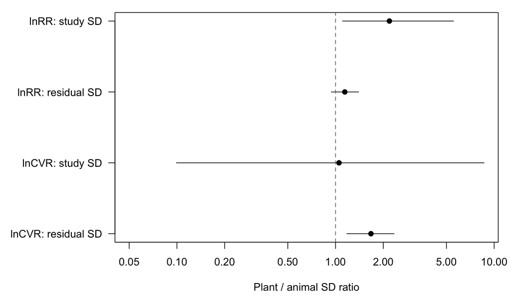

Posterior median and 95% credible interval for plant-to-animal residual and study SD ratios under the primary prior. The dashed line denotes equal SDs.

```r
ratio_plot_data <- study_level_models[
  study_level_models$engine == "brms" &
    grepl("extended_primary$", study_level_models$model) &
    study_level_models$component == "ratio",
  c("response", "term", "estimate", "lower", "upper")
]
ratio_plot_data$label <- paste(
  ratio_plot_data$response,
  ifelse(grepl("study", ratio_plot_data$term), "study SD", "residual SD"),
  sep = ": "
)
ratio_plot_data <- ratio_plot_data[order(ratio_plot_data$response, ratio_plot_data$term), ]
old_par <- par(mar = c(5, 9, 1, 1))
plot(
  ratio_plot_data$estimate,
  seq_len(nrow(ratio_plot_data)),
  xlim = range(c(0.05, ratio_plot_data$lower, ratio_plot_data$upper)),
  log = "x",
  yaxt = "n",
  ylab = "",
  xlab = "Plant / animal SD ratio",
  pch = 19
)
segments(
  ratio_plot_data$lower,
  seq_len(nrow(ratio_plot_data)),
  ratio_plot_data$upper,
  seq_len(nrow(ratio_plot_data))
)
abline(v = 1, lty = 2, col = "grey40")
axis(2, at = seq_len(nrow(ratio_plot_data)), labels = ratio_plot_data$label, las = 1)
```

```r
par(old_par)
```

For lnRR, the plant study SD was larger than the animal study SD: $R_u=2.18$ (95% CrI 1.11–5.55). The residual-SD ratio was less certain, $R_e=1.14$ (0.94–1.40). For lnCVR, the residual SD was larger under plant fertiliser, $R_e=1.67$ (1.18–2.34), whereas the study-SD ratio was estimated imprecisely, $R_u=1.05$ (0.10–8.63). Changing the prior on the study SD did not alter these interpretations.

### How both levels enter prediction

For a new study in category $g$, the latent effect has predictive variance

$$\operatorname{Var}(y_{\mathrm{latent,new},g})=
\sigma_{u,g}^2+\sigma_{e,g}^2.$$

An observed effect adds its sampling variance:

$$\operatorname{Var}(y_{\mathrm{observed,new},g})=
\sigma_{u,g}^2+\sigma_{e,g}^2+v_{\mathrm{new}}.$$

For the mean of $k$ effects from one new study,

$$\operatorname{Var}(\bar y_{\mathrm{new},g})=
\sigma_{u,g}^2+\frac{\sigma_{e,g}^2}{k}+
\frac{\mathbf 1^\top\mathbf V_{\mathrm{new}}\mathbf 1}{k^2}.$$

Increasing $k$ averages down residual and sampling variation, but it does not average away the study-level component. The intervals below include posterior uncertainty in the means and variance components.

```r
prediction_targets <- study_level_predictions[
  grepl("extended_primary$", study_level_predictions$model) &
    study_level_predictions$vi_scenario == "median" &
    study_level_predictions$term %in% c("latent_new_effect", "observed_new_effect"),
  c("response", "fertilizer", "term", "median", "q2.5", "q97.5", "interval_width")
]
prediction_targets <- prediction_targets[order(
  prediction_targets$response,
  prediction_targets$fertilizer,
  prediction_targets$term
), ]
knitr::kable(round_numeric_columns(prediction_targets), row.names = FALSE)
```

Latent and observed new-effect prediction intervals at category-specific median sampling variance.

| response | fertilizer | term | median | q2.5 | q97.5 | interval_width |
| --- | --- | --- | --- | --- | --- | --- |
| lnCVR | animal | latent_new_effect | 0.268 | -0.797 | 1.248 | 2.045 |
| lnCVR | animal | observed_new_effect | 0.262 | -1.302 | 1.790 | 3.092 |
| lnCVR | plant | latent_new_effect | 0.378 | -1.163 | 2.003 | 3.167 |
| lnCVR | plant | observed_new_effect | 0.392 | -1.723 | 2.440 | 4.163 |
| lnRR | animal | latent_new_effect | -0.205 | -0.830 | 0.388 | 1.219 |
| lnRR | animal | observed_new_effect | -0.224 | -0.866 | 0.435 | 1.301 |
| lnRR | plant | latent_new_effect | -0.466 | -1.353 | 0.480 | 1.833 |
| lnRR | plant | observed_new_effect | -0.470 | -1.406 | 0.501 | 1.907 |

```r
mean_k_predictions <- study_level_predictions[
  grepl("extended_primary$", study_level_predictions$model) &
    study_level_predictions$vi_scenario == "median" &
    study_level_predictions$term %in% c(
      "mean_of_1_new_effects",
      "mean_of_5_new_effects",
      "mean_of_10_new_effects"
    ),
  c("response", "fertilizer", "k", "vi", "median", "q2.5", "q97.5", "interval_width")
]
mean_k_predictions <- mean_k_predictions[order(
  mean_k_predictions$response,
  mean_k_predictions$fertilizer,
  mean_k_predictions$k
), ]
knitr::kable(round_numeric_columns(mean_k_predictions), row.names = FALSE)
```

Prediction intervals for the mean of k effects from one new study at category-specific median sampling variance.

| response | fertilizer | k | vi | median | q2.5 | q97.5 | interval_width |
| --- | --- | --- | --- | --- | --- | --- | --- |
| lnCVR | animal | 1 | 0.335 | 0.262 | -1.302 | 1.790 | 3.092 |
| lnCVR | animal | 5 | 0.335 | 0.277 | -0.574 | 1.112 | 1.686 |
| lnCVR | animal | 10 | 0.335 | 0.265 | -0.393 | 0.950 | 1.343 |
| lnCVR | plant | 1 | 0.503 | 0.392 | -1.723 | 2.440 | 4.163 |
| lnCVR | plant | 5 | 0.503 | 0.383 | -0.706 | 1.454 | 2.160 |
| lnCVR | plant | 10 | 0.503 | 0.385 | -0.468 | 1.299 | 1.768 |
| lnRR | animal | 1 | 0.012 | -0.224 | -0.866 | 0.435 | 1.301 |
| lnRR | animal | 5 | 0.012 | -0.211 | -0.631 | 0.210 | 0.841 |
| lnRR | animal | 10 | 0.012 | -0.219 | -0.605 | 0.154 | 0.759 |
| lnRR | plant | 1 | 0.007 | -0.470 | -1.406 | 0.501 | 1.907 |
| lnRR | plant | 5 | 0.007 | -0.455 | -1.229 | 0.320 | 1.549 |
| lnRR | plant | 10 | 0.007 | -0.465 | -1.218 | 0.298 | 1.516 |

For lnRR, the plant prediction remains materially wider as $k$ increases because its study-level component is larger. This supports, with qualification, poorer transferability of the lnRR study-level mean under plant fertiliser; predictions for individual effects are also wider. For lnCVR, the unresolved study-SD contrast does not establish poorer transferability of the study-level mean. Predictions for individual effects in a new plant-fertiliser study are nevertheless wider because residual heterogeneity also contributes.

### Matched-subset direct study-scale analysis

The direct `drmTMB` model places fertiliser predictors on both the residual and study SDs. It uses the 30 studies in which fertiliser category is constant.

```r
drmTMB::drmTMB(
  drmTMB::bf(
    response ~ fertilizer + (1 | study_ID) + drmTMB::meta_V(V = V),
    sigma ~ 0 + fertilizer,
    sd(study_ID) ~ 0 + fertilizer
  ),
  family = gaussian(),
  data = matched_data,
  REML = FALSE
)
```

`blsmeta` fits the same matched-subset model in a Bayesian framework, using `mods_scale2` for the residual SD and `mods_scale3` for the study SD. The observations are sorted by study before creating the numeric study index required by the model.

```r
matched_data <- matched_data[
  order(matched_data$study_ID, matched_data$effect_size_ID),
]
matched_data$es_blsmeta <- seq_len(nrow(matched_data))
matched_data$study_blsmeta <- blsmeta::make_study_id(matched_data$study_ID)

blsmeta_lnRR <- blsmeta::blsmeta(
  yi = lnRR,
  vi = var.lnRR,
  es_id = es_blsmeta,
  study_id = study_blsmeta,
  mods = ~ fertilizer,
  mods_scale2 = ~ 0 + fertilizer,
  mods_scale3 = ~ 0 + fertilizer,
  iter = 20000,
  warmup = 5000,
  chains = 4,
  data = matched_data
)

# Repeat with yi = lnCVR and vi = var.lnCVR.
```

The frequentist matched-subset categorical bridge and direct model use exactly the same 232 effects, although `metafor` uses REML and `drmTMB` uses ML. They agree that the lnRR study SD is greater for plant fertiliser. For lnCVR, these two frequentist fits place the plant study SD near zero, but the direct fit is on a weakly identified boundary; that result is not evidence of zero plant study heterogeneity.

```r
direct_results <- study_level_models[
  study_level_models$data_scope == "matched_subset_232_effects_30_studies" &
    study_level_models$model %in% c(
      "metafor_DIAG_bridge", "drmTMB_direct_study_scale",
      "blsmeta_direct_study_scale"
    ) &
    study_level_models$component == "ratio",
  c("response", "engine", "model", "term", "estimate", "lower", "upper", "diagnostic_status", "boundary")
]
knitr::kable(round_numeric_columns(direct_results), row.names = FALSE)
```

Matched-subset categorical bridge and direct study-scale SD ratios.

| response | engine | model | term | estimate | lower | upper | diagnostic_status | boundary |
| --- | --- | --- | --- | --- | --- | --- | --- | --- |
| lnRR | metafor | metafor_DIAG_bridge | residual_plant_animal | 1.115 | NA | NA | not_assessed | NA |
| lnRR | metafor | metafor_DIAG_bridge | study_plant_animal | 2.584 | NA | NA | not_assessed | NA |
| lnCVR | metafor | metafor_DIAG_bridge | residual_plant_animal | 2.137 | NA | NA | not_assessed | NA |
| lnCVR | metafor | metafor_DIAG_bridge | study_plant_animal | 0.000 | NA | NA | not_assessed | NA |
| lnRR | drmTMB | drmTMB_direct_study_scale | residual_plant_animal | 1.114 | NA | NA | ok | NA |
| lnRR | drmTMB | drmTMB_direct_study_scale | study_plant_animal | 2.605 | NA | NA | ok | NA |
| lnCVR | drmTMB | drmTMB_direct_study_scale | residual_plant_animal | 2.122 | NA | NA | warning_or_boundary | TRUE |
| lnCVR | drmTMB | drmTMB_direct_study_scale | study_plant_animal | 0.000 | NA | NA | warning_or_boundary | TRUE |
| lnRR | blsmeta | blsmeta_direct_study_scale | residual_plant_animal | 1.113 | 0.891 | 1.402 | failed_convergence | NA |
| lnRR | blsmeta | blsmeta_direct_study_scale | study_plant_animal | 2.505 | 1.005 | 6.595 | failed_convergence | NA |
| lnCVR | blsmeta | blsmeta_direct_study_scale | residual_plant_animal | 2.111 | 1.469 | 3.033 | failed_convergence | NA |
| lnCVR | blsmeta | blsmeta_direct_study_scale | study_plant_animal | 0.854 | 0.200 | 3.842 | failed_convergence | NA |

The matched-subset estimates support the larger plant study SD for lnRR. For lnCVR, the frequentist study-SD estimates lie near a boundary and the Bayesian interval is wide. The `blsmeta` chains did not meet the convergence criteria for all study-scale parameters, so these estimates are included only as a sensitivity analysis.

### Model checks and limitations

```r
diagnostic_table <- study_level_diagnostics[, c(
  "response", "engine", "model", "diagnostic_status",
  "max_rhat", "min_ess_bulk", "divergences", "boundary",
  "exploratory_only"
)]
knitr::kable(round_numeric_columns(diagnostic_table), row.names = FALSE)
```

Concise fit diagnostics for the study-level extension.

| response | engine | model | diagnostic_status | max_rhat | min_ess_bulk | divergences | boundary | exploratory_only |
| --- | --- | --- | --- | --- | --- | --- | --- | --- |
| lnRR | metafor | primary_diag | converged;unavailable;unavailable;clear | NA | NA | NA | FALSE | FALSE |
| lnRR | glmmTMB | primary_glmmTMB | converged;available;positive_definite;clear | NA | NA | NA | FALSE | FALSE |
| lnRR | metafor | sensitivity_un | converged;unavailable;unavailable;at_or_near_boundary | NA | NA | NA | TRUE | TRUE |
| lnCVR | metafor | primary_diag | converged;unavailable;unavailable;clear | NA | NA | NA | FALSE | FALSE |
| lnCVR | glmmTMB | primary_glmmTMB | converged;available;positive_definite;clear | NA | NA | NA | FALSE | FALSE |
| lnCVR | metafor | sensitivity_un | converged;unavailable;unavailable;at_or_near_boundary | NA | NA | NA | TRUE | TRUE |
| lnCVR | brms | lnCVR_baseline_primary | passed | 1.004 | 1520.065 | 0 | FALSE | FALSE |
| lnCVR | brms | lnCVR_extended_primary | passed | 1.006 | 1071.193 | 0 | FALSE | FALSE |
| lnCVR | brms | lnCVR_extended_sd_prior_sensitivity | passed | 1.005 | 1149.142 | 0 | FALSE | FALSE |
| lnRR | brms | lnRR_baseline_primary | passed | 1.004 | 1142.862 | 0 | FALSE | FALSE |
| lnRR | brms | lnRR_extended_primary | passed | 1.008 | 1002.119 | 0 | FALSE | FALSE |
| lnRR | brms | lnRR_extended_sd_prior_sensitivity | passed | 1.004 | 1184.192 | 0 | FALSE | FALSE |
| lnRR | drmTMB | drmTMB_common_study_scale | ok | NA | NA | NA | FALSE | FALSE |
| lnRR | drmTMB | drmTMB_direct_study_scale | ok | NA | NA | NA | FALSE | FALSE |
| lnCVR | drmTMB | drmTMB_common_study_scale | ok | NA | NA | NA | FALSE | FALSE |
| lnCVR | drmTMB | drmTMB_direct_study_scale | warning_or_boundary | NA | NA | NA | TRUE | FALSE |
| lnRR | blsmeta | blsmeta_direct_study_scale | failed_convergence | 1.144 | 46.431 | NA | FALSE | FALSE |
| lnCVR | blsmeta | blsmeta_direct_study_scale | failed_convergence | 1.010 | 1479.007 | NA | FALSE | FALSE |

- The full-data Bayesian fits have $\widehat R\leq1.01$, adequate bulk and tail effective sample sizes, and no unresolved divergences.
- `metafor` and `glmmTMB` agree on the primary frequentist point estimates.
- The exploratory animal–plant study correlation is at the boundary and is not interpreted.
- The lnCVR study SD is weakly identified in the matched subset.
- The `blsmeta` study-scale estimates are not interpreted because their convergence criteria were not met.

For lnRR, the evidence supports greater plant study-level heterogeneity and hence poorer transferability of the study-level mean, with a wide interval and the diagonal covariance assumption stated explicitly. For lnCVR, the evidence supports greater plant residual heterogeneity, but not a difference in transferability of the study-level mean; individual-effect predictions are wider under plant fertiliser.

# Software and package versions

# References

- Lauren C. Ponisio, Leithen K. M’Gonigle, Kevi C. Mace, Jenny Palomino, Perry de Valpine, Claire Kremen; Diversification practices reduce organic to conventional yield gap. Proc Biol Sci. 2015; 282 (1799): 20141396. https://doi.org/10.1098/rspb.2014.1396